# Homework #3

Jaxon Stuhr

2022-10-25

## Classification

For this assignment, we will be working with part of a [Kaggle data set](https://www.kaggle.com/c/titanic/overview) that was the subject of a machine learning competition and is often used for practicing ML models. The goal is classification; specifically, to predict which passengers would survive the [Titanic shipwreck](https://en.wikipedia.org/wiki/Titanic).

```r
# set seed for reproducibility
set.seed(147)
# load in titanic data
titanic_raw = read.csv(here("data", "titanic.csv")) %>%
  mutate(pclass = factor(pclass),
         survived = factor(survived, levels = c("Yes", "No") ))
```

### Question 1

```r
titanic_split <- initial_split(titanic_raw, prop = 0.75,
                                strata = "survived")
titanic_train <- training(titanic_split)
titanic_test <- testing(titanic_split)

summary(titanic_train)
```

```
##   passenger_id   survived  pclass      name               sex
##  Min.   :  1.0   Yes:256   1:167   Length:667         Length:667
##  1st Qu.:223.5   No :411   2:134   Class :character   Class :character
##  Median :438.0             3:366   Mode  :character   Mode  :character
##  Mean   :441.1
##  3rd Qu.:663.5
##  Max.   :891.0
##
##       age            sib_sp           parch           ticket
##  Min.   : 0.67   Min.   :0.0000   Min.   :0.0000   Length:667
##  1st Qu.:21.00   1st Qu.:0.0000   1st Qu.:0.0000   Class :character
##  Median :28.00   Median :0.0000   Median :0.0000   Mode  :character
##  Mean   :30.20   Mean   :0.5127   Mean   :0.3673
##  3rd Qu.:39.25   3rd Qu.:1.0000   3rd Qu.:0.0000
##  Max.   :80.00   Max.   :8.0000   Max.   :6.0000
##  NA's   :127
##       fare            cabin             embarked
##  Min.   :  0.000   Length:667         Length:667
##  1st Qu.:  7.896   Class :character   Class :character
##  Median : 14.454   Mode  :character   Mode  :character
##  Mean   : 31.746
##  3rd Qu.: 30.848
##  Max.   :512.329
##
```

```r
sum(is.na(titanic_train$cabin))
```

```
## [1] 510
```

```r
death_prop = sum(titanic_raw$survived == "No")/length(titanic_raw$survived)
```

Stratified sampling is necessary due to the fact that the majority of passengers did NOT survive (~62% deceased).

### Question 2

```r
titanic_train_summary = titanic_train %>%
  group_by(survived, age) %>%
  summarise(count = n())
```

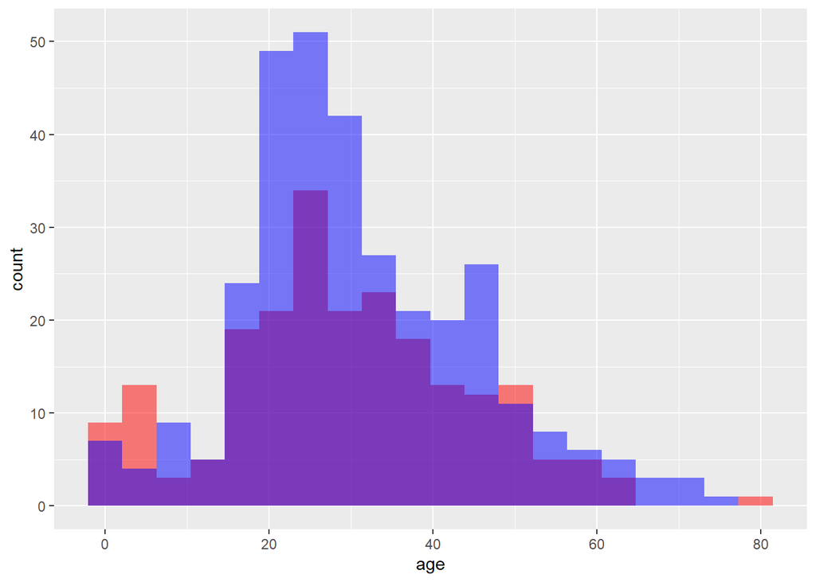

```r
ggplot() +
  geom_histogram(data = filter(titanic_train, survived == "Yes"), aes(x = age), bins = 20, fill = "red", alpha = .5) +
  geom_histogram(data = filter(titanic_train, survived == "No"), aes(x = age), bins = 20, fill = "blue", alpha = .5)
```

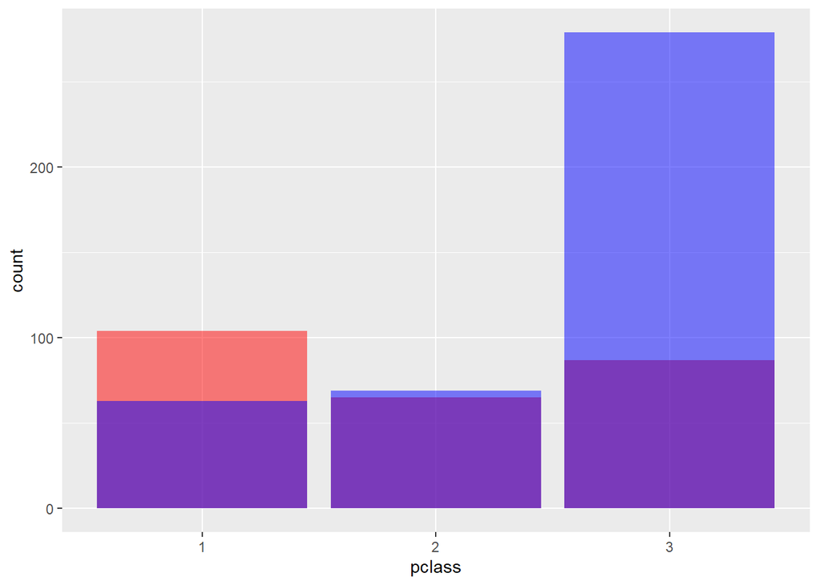

```r
ggplot() +
  geom_bar(data = filter(titanic_train, survived == "Yes"), aes(x = pclass), bins = 3, fill = "red", alpha = .5) +
  geom_bar(data = filter(titanic_train, survived == "No"), aes(x = pclass), bins = 3, fill = "blue", alpha = .5)
```

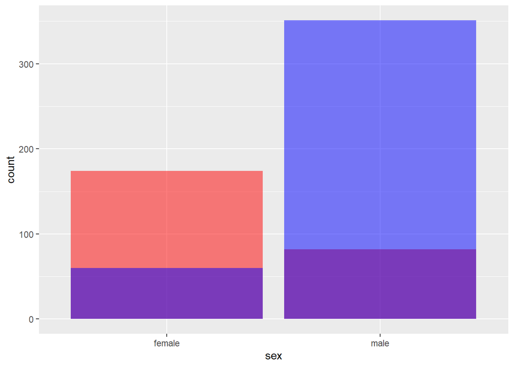

```r
ggplot() +
  geom_bar(data = filter(titanic_train, survived == "Yes"), aes(x = sex), bins = 2, fill = "red", alpha = .5) +
  geom_bar(data = filter(titanic_train, survived == "No"), aes(x = sex), bins = 2, fill = "blue", alpha = .5)
```

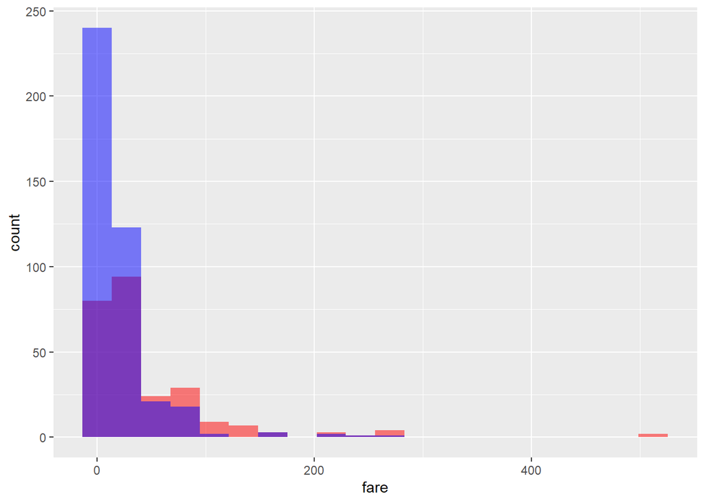

```r
ggplot() +
  geom_histogram(data = filter(titanic_train, survived == "Yes"), aes(x = fare), bins = 20, fill = "red", alpha = .5) +
  geom_histogram(data = filter(titanic_train, survived == "No"), aes(x = fare), bins = 20, fill = "blue", alpha = .5)
```

Based on the above distributions, we see significant correlations between sex and passenger class with whether or not an individual survived, and weaker relationships with age and fare paid.

### Question 3

Using the **training** data set, create a correlation matrix of all continuous variables. Create a visualization of the matrix, and describe any patterns you see. Are any predictors correlated with each other? Which ones, and in which direction?

```r
cor_titanic <- titanic_train %>%
  select(passenger_id, pclass, age, sib_sp, parch, fare) %>%
  correlate()
```

```
## Non-numeric variables removed from input: `pclass`
## Correlation computed with
## • Method: 'pearson'
## • Missing treated using: 'pairwise.complete.obs'
```

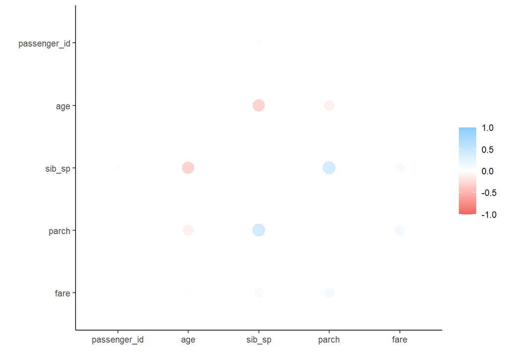

```r
rplot(cor_titanic)
```

### Question 4

```r
# generate recipe age as a function of all predictors
titanic_recipe <- recipe(survived ~ pclass + sex + age + sib_sp + parch + fare, data = titanic_train) %>%
  # add imputation for missing ages
  step_impute_linear(age) %>%
  # dummy vars for nominal predictors
  step_dummy(pclass, sex) %>%
  # set up interaction terms
  step_interact(terms = ~ starts_with("sex"):fare) %>%
  step_interact(terms = ~ age:fare) %>%
  # center
  step_center(all_numeric_predictors()) %>%
  # scale
  step_scale(all_numeric_predictors())
```

### Question 5

Logistic Regression (LR) Model + Fit

```r
# initialize model
lr_model <- logistic_reg() %>%
  set_engine("glm")

# set up empty workflow
lr_wflow <- workflow() %>%
  # add model
  add_model(lr_model) %>%
  # add recipe
  add_recipe(titanic_recipe)

# apply model to training data
lr_fit <- fit(lr_wflow, titanic_train)
```

### Question 6

Linear Discriminant Analysis (LDA) Model + Fit

```r
# initialize model
lda_model <- discrim_linear() %>%
  set_engine("MASS")

# set up empty workflow
lda_wflow <- workflow() %>%
  # add model
  add_model(lda_model) %>%
  # add recipe
  add_recipe(titanic_recipe)

# apply model to training data
lda_fit <- fit(lda_wflow, titanic_train)
```

### Question 7

Quadratic Discriminant Analysis (QDA) Model + Fit

```r
# initialize model
qda_model <- discrim_quad() %>%
  set_engine("MASS")

# set up empty workflow
qda_wflow <- workflow() %>%
  # add model
  add_model(qda_model) %>%
  # add recipe
  add_recipe(titanic_recipe)

# apply model to training data
qda_fit <- fit(qda_wflow, titanic_train)
```

### Question 8

Naive-Bayes Model + Fit

```r
# initialize model
nb_model <- naive_Bayes() %>%
  set_engine("klaR")

# set up empty workflow
nb_wflow <- workflow() %>%
  # add model
  add_model(nb_model) %>%
  # add recipe
  add_recipe(titanic_recipe)

# apply model to training data
nb_fit <- fit(nb_wflow, titanic_train)
```

### Question 9

Accuracy of all four models

```r
lr_acc <- metric_set(accuracy)
# predict logistic regression vals
titanic_lr <- predict(lr_fit, new_data = titanic_train %>% select(-survived))
# add original survival data to new dataset
titanic_lr <- bind_cols(titanic_lr, titanic_train %>% select(survived))
#
lr_acc(titanic_lr, truth = survived,
                estimate = .pred_class)
```

```
## # A tibble: 1 × 3
##   .metric  .estimator .estimate
##   <chr>    <chr>          <dbl>
## 1 accuracy binary         0.810
```

```r
lda_acc <- metric_set(accuracy)
# predict logistic regression vals
titanic_lda <- predict(lda_fit, new_data = titanic_train %>% select(-survived))
# add original survival data to new dataset
titanic_lda <- bind_cols(titanic_lda, titanic_train %>% select(survived))
#
lda_acc(titanic_lda, truth = survived,
                estimate = .pred_class)
```

```
## # A tibble: 1 × 3
##   .metric  .estimator .estimate
##   <chr>    <chr>          <dbl>
## 1 accuracy binary         0.798
```

```r
qda_acc <- metric_set(accuracy)
# predict logistic regression vals
titanic_qda <- predict(qda_fit, new_data = titanic_train %>% select(-survived))
# add original survival data to new dataset
titanic_qda <- bind_cols(titanic_qda, titanic_train %>% select(survived))
#
qda_acc(titanic_qda, truth = survived,
                estimate = .pred_class)
```

```
## # A tibble: 1 × 3
##   .metric  .estimator .estimate
##   <chr>    <chr>          <dbl>
## 1 accuracy binary         0.774
```

```r
nb_acc <- metric_set(accuracy)
# predict logistic regression vals
titanic_nb <- predict(nb_fit, new_data = titanic_train %>% select(-survived))
# add original survival data to new dataset
titanic_nb <- bind_cols(titanic_nb, titanic_train %>% select(survived))
#
nb_acc(titanic_nb, truth = survived,
                estimate = .pred_class)
```

```
## # A tibble: 1 × 3
##   .metric  .estimator .estimate
##   <chr>    <chr>          <dbl>
## 1 accuracy binary         0.789
```

The logistic regression model performed best, with an accuracy of 81%.

### Question 10

Model Performance on Titanic Testing Data

```r
lr_acc_testing <- metric_set(accuracy)
# predict logistic regression vals
titanic_lr_testing <- predict(lr_fit, new_data = titanic_test %>% select(-survived))
# add original survival data to new dataset
titanic_lr_testing <- bind_cols(titanic_lr_testing, titanic_test %>% select(survived))
#
lr_acc_testing(titanic_lr_testing, truth = survived,
                estimate = .pred_class)
```

```
## # A tibble: 1 × 3
##   .metric  .estimator .estimate
##   <chr>    <chr>          <dbl>
## 1 accuracy binary         0.812
```

The logistic regression model had an accuracy of 81% on the testing data, within .3% of its accuracy on the training data. Any differences are likely simply due to random chance. We do not appear to have overfit the model to the training data or we would have expected it to perform worse on the testing data.

Confusion Matrix:

```r
confusionMatrix(data = titanic_lr_testing$.pred_class, reference = titanic_lr_testing$survived)
```

```
## Confusion Matrix and Statistics
##
##           Reference
## Prediction Yes  No
##        Yes  59  15
##        No   27 123
##
##                Accuracy : 0.8125
##                  95% CI : (0.7551, 0.8614)
##     No Information Rate : 0.6161
##     P-Value [Acc > NIR] : 1.684e-10
##
##                   Kappa : 0.5929
##
##  Mcnemar's Test P-Value : 0.08963
##
##             Sensitivity : 0.6860
##             Specificity : 0.8913
##          Pos Pred Value : 0.7973
##          Neg Pred Value : 0.8200
##              Prevalence : 0.3839
##          Detection Rate : 0.2634
##    Detection Prevalence : 0.3304
##       Balanced Accuracy : 0.7887
##
##        'Positive' Class : Yes
##
```

ROC Curve + Area

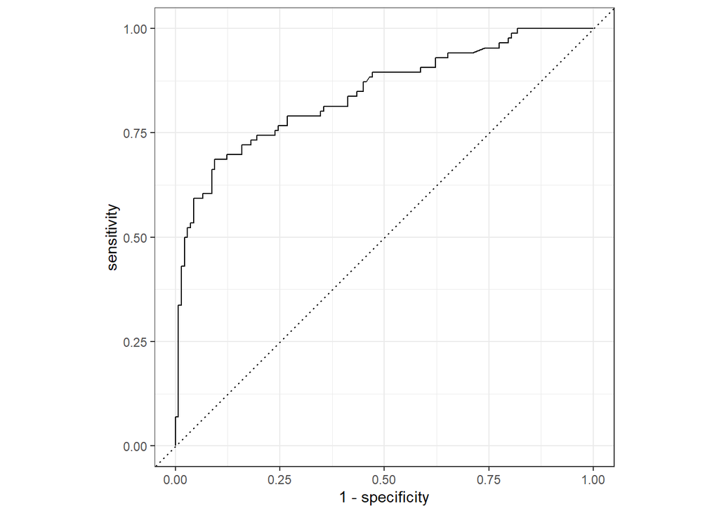

```r
# calculate survival probabilities from data
titanic_lr_testing_probs <- predict(lr_fit,
                                    new_data = titanic_test %>% select(-survived),
                                    type = "prob")
# add original survival data to new dataset
titanic_lr_testing_probs <- bind_cols(titanic_lr_testing_probs,
                                titanic_test %>% select(survived))
# plot roc curve
roc_curve(titanic_lr_testing_probs, .pred_Yes, truth = survived) %>%
  autoplot()
```

```r
# calculate AUC
titanic_lr_testing_probs %>%
  roc_auc(truth = survived, .pred_Yes)
```

```
## # A tibble: 1 × 3
##   .metric .estimator .estimate
##   <chr>   <chr>          <dbl>
## 1 roc_auc binary         0.844
```

Above is the plotted ROC Curve, with a calculated AUC of .844

### Required for 231 Students

In a binary classification problem, let $p$ represent the probability of class label $1$, which implies that $1 - p$ represents the probability of class label $0$. The *logistic function* (also called the “inverse logit”) is the cumulative distribution function of the logistic distribution, which maps a real number *z* to the open interval $(0, 1)$.

### Question 11

$$p(z)=\frac{e^z}{1+e^z} = 1- \frac{1}{1+e^z}$$

$$=> 1-p = \frac{1}{1-e^z} => 1 + e^z = \frac{1}{1-p} => e^z =
\frac{p}{1-p}$$

$$=> ln(e^z)=ln\left(\frac{p}{1-p}\right) =>
z=ln\left(\frac{p}{1-p}\right)$$

### Question 12

Assume that $z = \beta_0 + \beta_{1}x_{1}$ and $p = logistic(z)$. How do the odds of the outcome change if you increase $x_{1}$ by two? Demonstrate this.

Assume now that $\beta_1$ is negative. What value does $p$ approach as $x_{1}$ approaches $\infty$? What value does $p$ approach as $x_{1}$ approaches $-\infty$?

$$p(x_{1}) = 1-\frac{1}{1+e^{\beta_0 + \beta_{1}x_{1}}}$$
$$p(x_{1}+2) = 1-\frac{1}{1+e^{\beta_0 + \beta_{1}x_{1} + 2\beta_{1}}}$$

$$=> \Delta p = p(x_{1}+2) - p(x_{1}) = -\frac{1}{1+e^{\beta_0 +
\beta_{1}x_{1} + 2\beta_{1}}} + \frac{1}{1+e^{\beta_0 + \beta_{1}x_{1}}}$$

$$= \frac{1}{1+e^{\beta_0} * e^{\beta_{1}x_{1}}} - \frac{1}{1+e^{\beta_0}
* e^{\beta_{1}x_{1}}* e^ {2\beta_{1}}}$$

$$=(e^{2\beta_{1}} - 1)* \frac{
e^{\beta_0 + \beta_{1}x_{1}}}{
1+e^{\beta_0 + \beta_{1}x_{1}}+e^{\beta_0 + \beta_{1}x_{1}+2\beta_{1}}
+e^{2[\beta_0+\beta_{1}(1+x)]}
}$$

Thus if you increase $x_{1}$ by 2, if $\beta_1 > 0$ then $p$ will increase, if $\beta_1 < 0$ then $p$ will decrease, and if $\beta_1=0$ then $p$ will not change.

Assuming $\beta_1 < 0$, as $x_{1}$ approaches $\infty$ $p$ will approach zero, and as $x_{1}$ approaches $-\infty$ $p$ will approach 1.